# Red Wine Exploration by Ryan Reardon

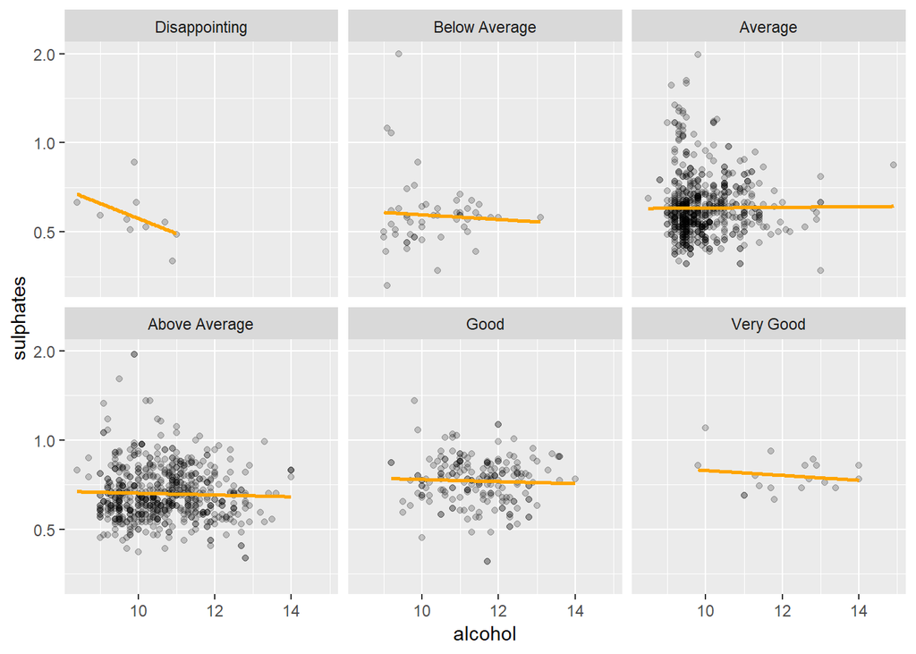

#### Observations from the scatter plot comparing sulphates to alcohol by quality rating:

- In the bivariate section, alcohol and sulphates seemed to increase as the rating of wine got better.
- Looking at the above plots, sulphate concentration does improve with rating as does alcohol percentage.
- The relationship between sulphates and alcohol percentage is very weak, showing a slight negative correlation across quality ratings.

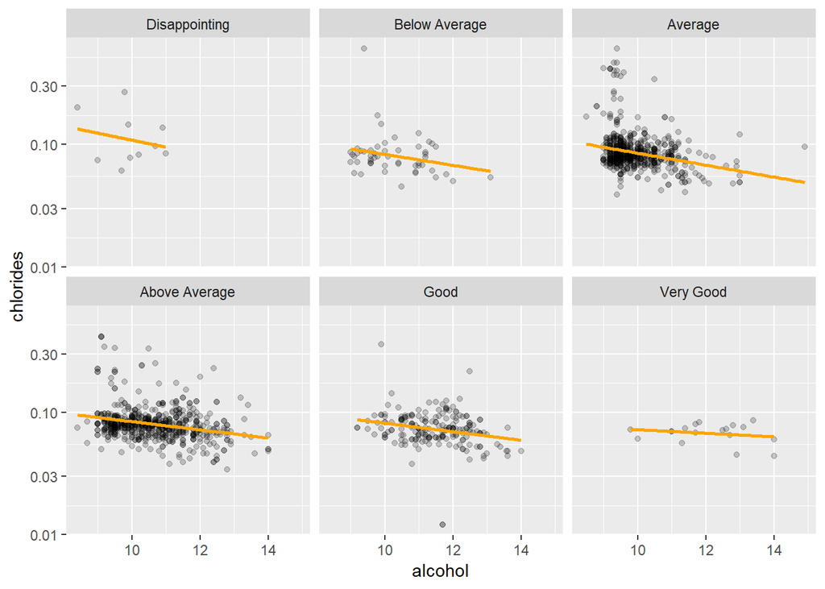

#### Observations from the scatter plot comparing chlorides to alcohol by quality rating:

- As rating increases chlorides (saltiness) decreases and alcohol percentage increases.
- There’s weak negative correlation between chlorides and alcohol that is more noticeable in lower quality wines.
- Better wines seem to be produced if chloride concentration is lower and alcohol percentage is higher.

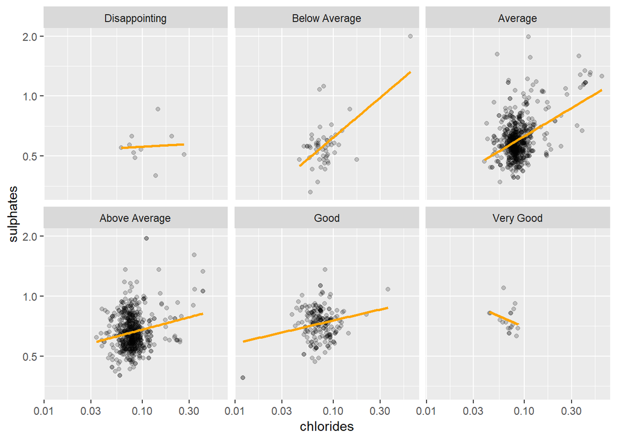

#### Observations from the scatter plot comparing sulphates to chlorides by quality rating:

- In the bivariate analysis, better wines have more sulphates and less chlorides; chlorides and sulphates had a low moderate postive correlation.
- Looking at the plots above; this is true, but it does show chlorides increasing and sulphates increasing for most categories just in smaller amounts as the rating increases.
- The exception is wines in the very good category.

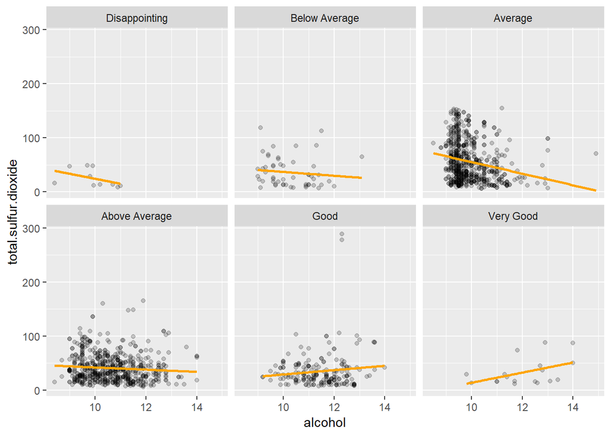

#### Observations from the scatter plot comparing total sulfur dioxide to alcohol by quality rating:

- Sulfur dioxide concentrations don’t seem to affect the quality of the wine.
- Disappointing wines have low sulfur dioxide as does wines rated very good.
- Average and above average wines tend to show more variation, but this seems related more so to outliers.
- Total sulfur dioxide has weak negative correlation with alcohol its skewed by the outliers in average rated wines.

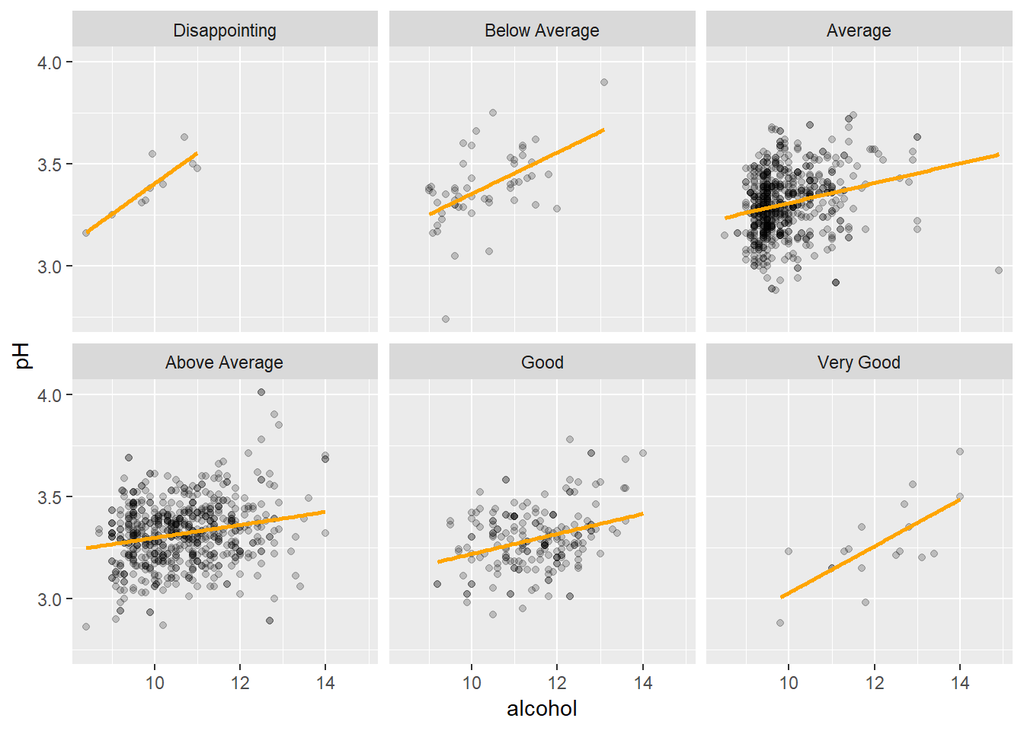

#### Observations from the scatter plot comparing ph to alcohol by quality rating:

- Alcohol and pH have a high weak positve correlation; as pH increases, the alcohol percentage increases.
- Most wines range in ph from 3 to 3.5.
- Better wines have higer percentages of alcohol and their ph levels are bit lower.

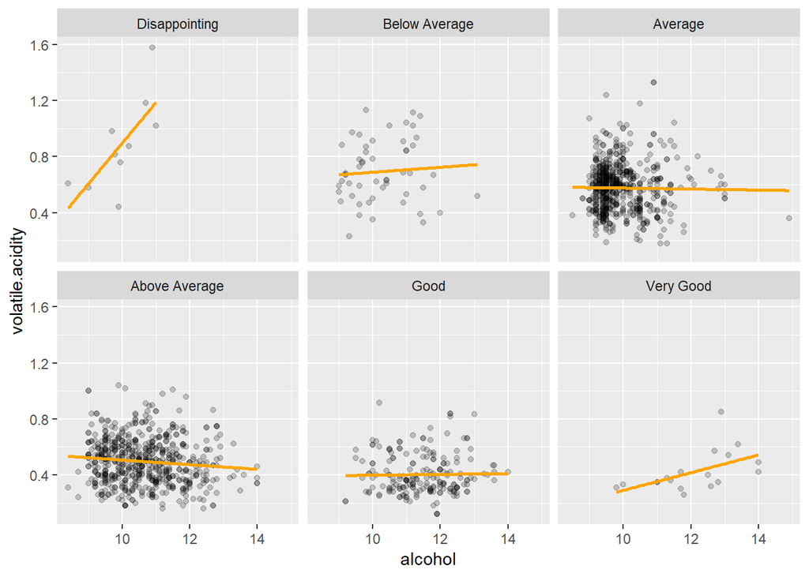

#### Observations from the scatter plot comparing alcohol to volatile acidity by quality rating:

- Lower concentrations of volatile acid and higher alcohol percentage seem to produce better wines. but it’s not exactly true.
- It looks like very good wines although have low volatile acid levels on average seem to increase as alchohol percentage increase and poorer rated wines tend to follow this patter too.
- Another interesting observation average to good rated wines negative correlation is very small; really small and almost none existant in average and good rated wines.

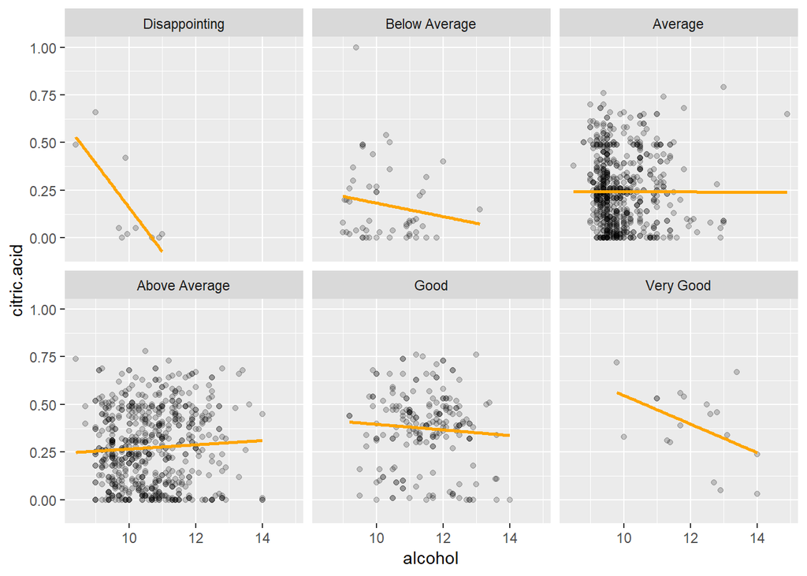

#### Observations from the scatter plot comparing citric acid to alcohol by quality rating:

- Better wines tend to have higher concentrations of citric acid and a higher alcohol percentage.
- As a whole, it’s a very weak positive correlation between citric acid and alcohol.
- You can see average and above average rated wines are the reason for this trend. Very good wines that have higher citric acid percentage have lower alcohol percentages as well as poorer wines.

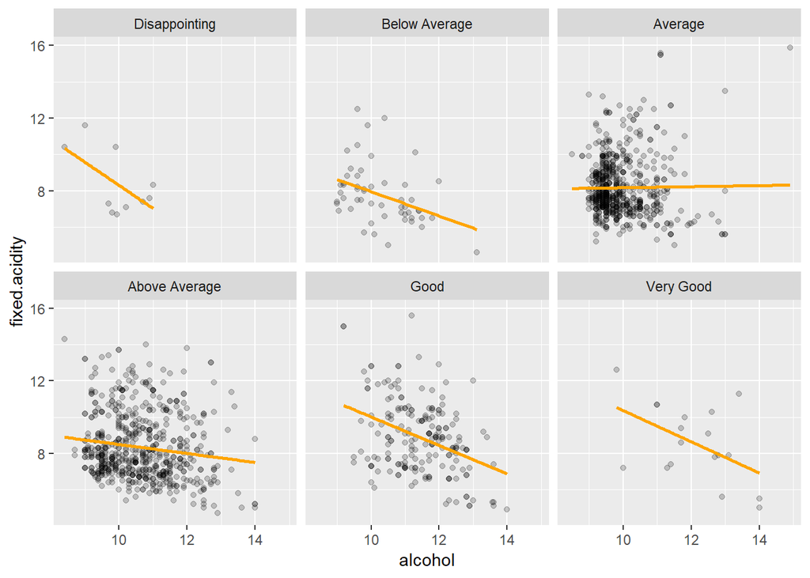

#### Observations from the scatter plot comparing fixed acidity to alcohol by quality rating:

- Alchol has very weak negative correlation with fixed acids.
- As alcohol increases; fixed acids decrease, this is more prevalent in better rated wines.

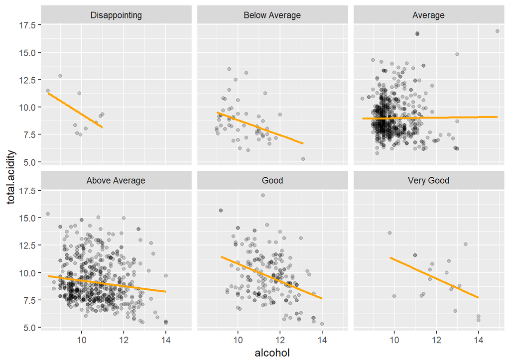

#### Observations from the scatter plot comparing total acidity to alcohol by quality rating:

- Similar to fixed acidity which make sense, fixed acids make up the the majority of total acids.

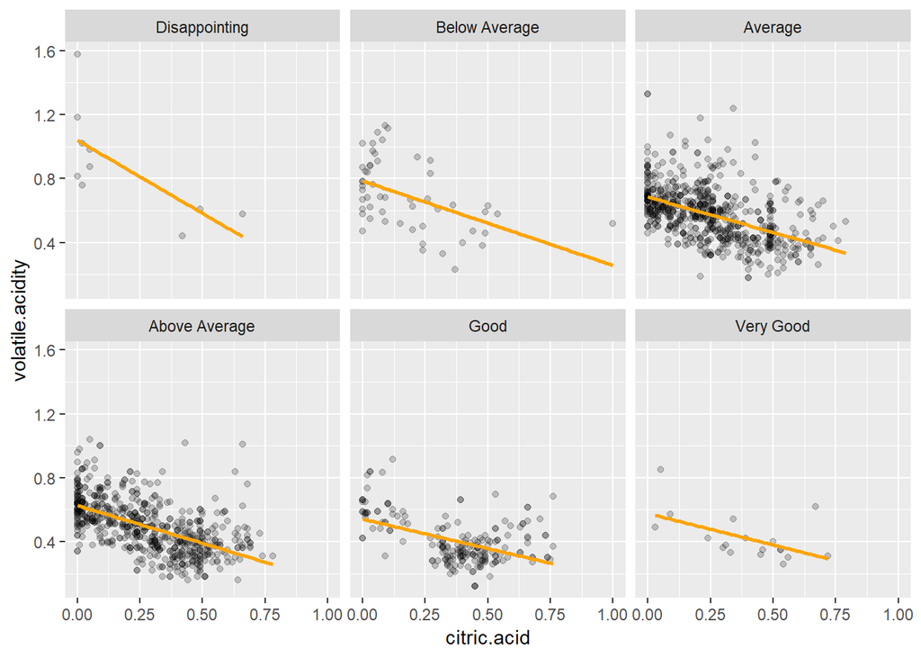

#### Observations from the scatter plot comparing citric acid to volatile acidity by quality rating:

- Lower volatile acid concentrations and high citric acid levels produce better wines.

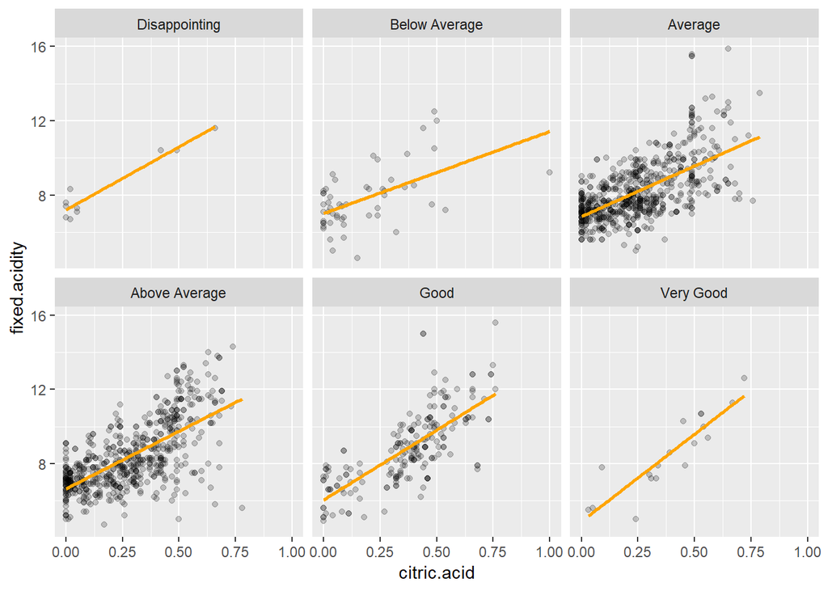

#### Observations from the scatter plot comparing fixed acidity to citric acid by quality rating:

- Fixed acidity and citric acid have a high moderate positve correlation as citric acid concentrations raises, so does fixed acid.
- Fixed acids ranges from 8 to 12 across all categories, but citric acid concentration is a higher on average in the better wines.

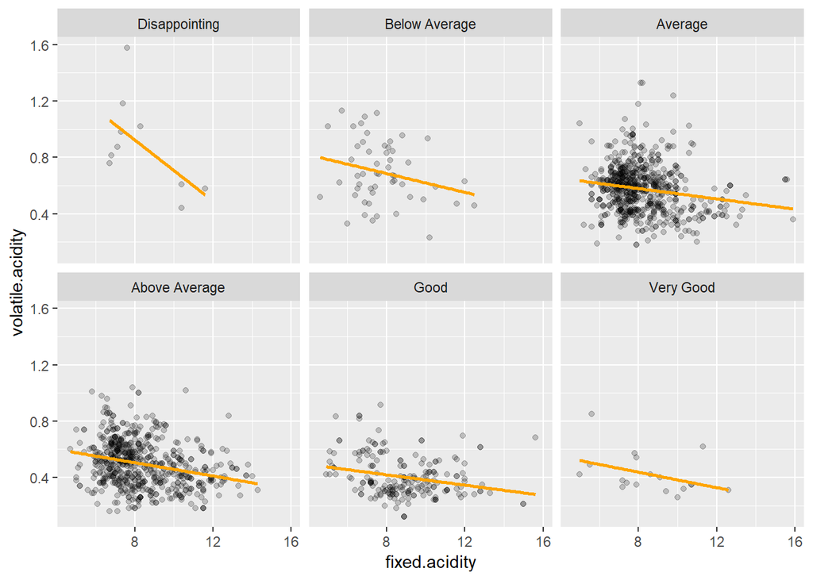

#### Observations from the scatter plot comparing fixed acidity to volatile acidity by quality rating:

- Weak negative correlation between volatile acid and fixed acid.
- Higher fixed acids and lower volatile acids produce better wines.

## Linear modeling

### Linear model with the variables most associated with quality either directly or indirectly

```
##
## Calls:
## lm1: lm(formula = quality ~ alcohol, data = rw)
## lm2: lm(formula = quality ~ alcohol + density, data = rw)
## lm3: lm(formula = quality ~ alcohol + density + sulphates, data = rw)
## lm4: lm(formula = quality ~ alcohol + density + sulphates + chlorides,
##     data = rw)
## lm5: lm(formula = quality ~ alcohol + density + sulphates + chlorides +
##     total.sulfur.dioxide, data = rw)
## lm6: lm(formula = quality ~ alcohol + density + sulphates + chlorides +
##     total.sulfur.dioxide + pH, data = rw)
## lm7: lm(formula = quality ~ alcohol + density + sulphates + chlorides +
##     total.sulfur.dioxide + pH + fixed.acidity, data = rw)
## lm8: lm(formula = quality ~ alcohol + density + sulphates + chlorides +
##     total.sulfur.dioxide + pH + fixed.acidity + volatile.acidity,
##     data = rw)
## lm9: lm(formula = quality ~ alcohol + density + sulphates + chlorides +
##     total.sulfur.dioxide + pH + fixed.acidity + volatile.acidity +
##     citric.acid, data = rw)
##
## ======================================================================================================================================================
##                             lm1           lm2           lm3           lm4           lm5           lm6           lm7           lm8           lm9
## ------------------------------------------------------------------------------------------------------------------------------------------------------
##   (Intercept)              -0.125       -35.152**     -13.045       -13.843       -10.813         9.347        31.944         8.010         6.571
##                            (0.175)      (10.878)      (10.872)      (10.771)      (10.709)      (11.003)      (17.398)      (17.027)      (17.045)
##   alcohol                   0.361***      0.391***      0.357***      0.332***      0.312***      0.316***      0.295***      0.286***      0.293***
##                            (0.017)       (0.019)       (0.019)       (0.019)       (0.020)       (0.019)       (0.023)       (0.022)       (0.023)
##   density                                34.822**      12.360        13.459        10.729        -6.848       -30.430        -5.765        -4.343
##                                         (10.813)      (10.819)      (10.719)      (10.655)      (10.848)      (17.763)      (17.387)      (17.404)
##   sulphates                                             0.967***      1.215***      1.259***      1.189***      1.196***      0.896***      0.898***
##                                                        (0.105)       (0.113)       (0.113)       (0.112)       (0.112)       (0.112)       (0.112)
##   chlorides                                                          -2.281***     -2.331***     -2.755***     -2.611***     -1.994***     -1.827***
##                                                                      (0.407)       (0.405)       (0.404)       (0.413)       (0.405)       (0.419)
##   total.sulfur.dioxide                                                             -0.003***     -0.003***     -0.002***     -0.002***     -0.002***
##                                                                                    (0.001)       (0.001)       (0.001)       (0.001)       (0.001)
##   pH                                                                                             -0.784***     -0.546**      -0.422*       -0.442*
```

[output cut: 19 more lines]

- With the additional variables in our model the R squared value is only .36 or 36% of the variance; adding the additional variables only improved our R suared statistic .14 or 14%. This model isn’t a great fit even with 9 variables and two missing. The data set isn’t very large and most of the data is concentrated around average and above average (5 or 6) quality rating.

# Multivariate Analysis

### Relationships Observed

#### Alcohol percentage, sulphate concentration and acidity levels are the underlying factors determining quality rating of the wine:

- Wines with higher alcohol percentage seem to get rated higher in quality.
- Sulphates in higer concentrations are rated higher.
- Citric acid added to wine seems to add in improving quality rating.
- Better wines do have lower volatile and fixed acid levels, but there’s caveat to volatile acid as it relates to rising alcohol levels.

### Interactions between Features

- The general rule is the higher ph; lower acid levels, we confirmed the correlation of volatile acid and ph turned positve was due to a lurking variable which switched the coefficient sign from postive to negative. I suspected that the higher alcohol percentage in the better wines had a relation, since winemakers due use methods to promote aerobic environments to enhance alcohol levels in wine during the fermentation process. Volatile acids tend to thrive in aerobic environments. Volatile acid to alcohol has a negative correlation, but it seems in better quality wines this trend reverses. Although the better quality wines do have lower volatile acid concentrations there does seem to be positve correlation of alcohol percentage and volatile acid levels in the better wines; especially, when wines get in the very good range.

### Linear Models

- Linear models created weren’t good fits. The first model of alcohol’s relationship to quality had a R squared value 22.6%; alcohol made up 22% of the variance. Adding the additional variables, only added an additional 14% for a total 36% variance with quality, so this model isn’t a good fit and wouldn’t suffice to explain the variance in quality rating.

# Final Plots and Summary

Throughtout the analysis, alcohol percentage played the largest role in determining how a wine is rated, but there were also other variables that had a indirect relationship in determining rating; sulphates and volatile acid, because of their relationship with alcohol. So, I decided include three plots that I thought best showed the relationships.

### Plot One

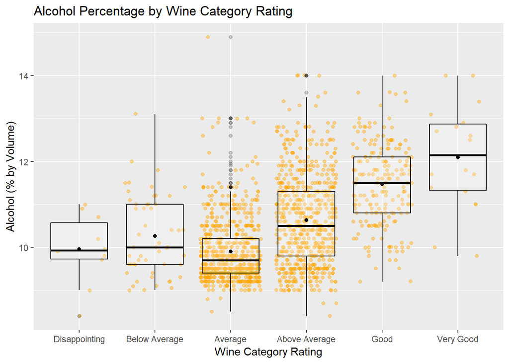

### Plot Two

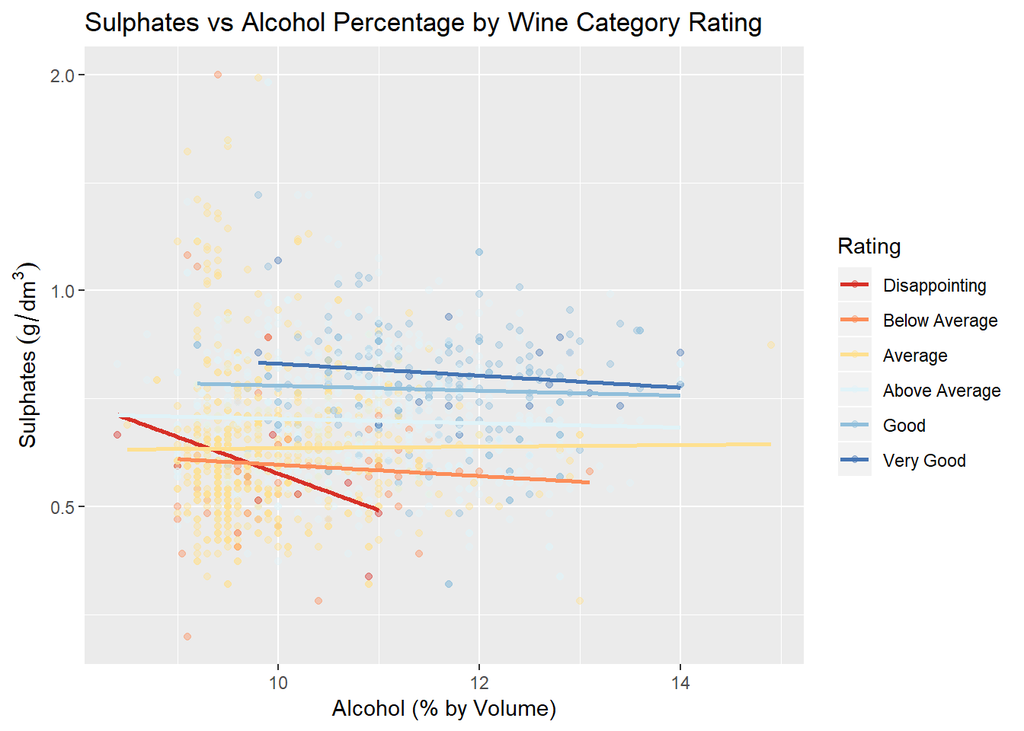

- Looking at the relationship between alcohol percentage and sulphates, we can clearly see we have very weak negative correlation except in lower quality wines it’s more noticeable. One thing the plot clearly shows, the combination of higher sulphate concentrations and higher alcohol percentages are rated higher. Higher concentrations of sulphates along with higher alcohol percentages seem to produce better wines, or get a higer rating.

### Plot Three

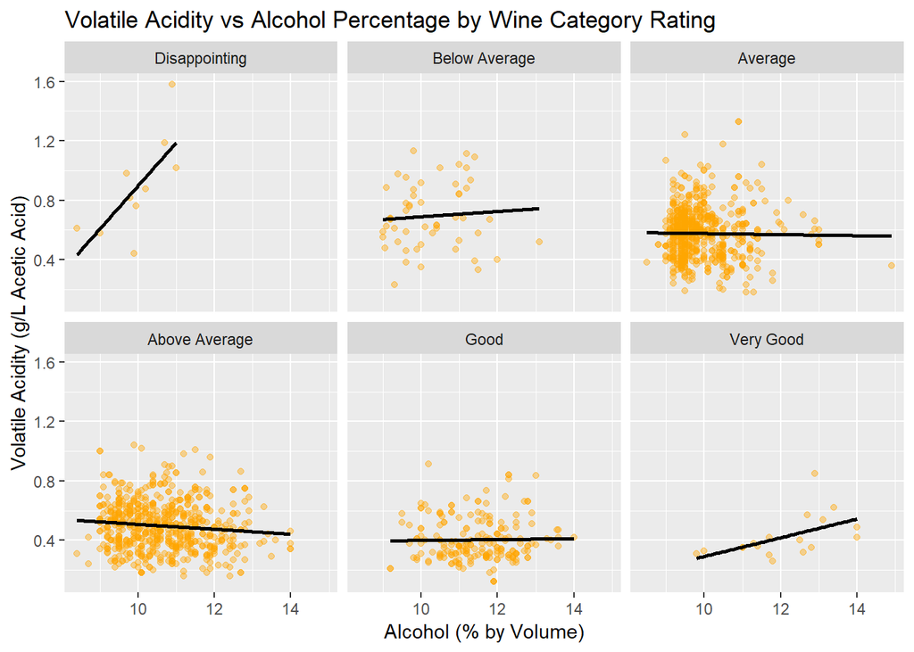

- Looking at the relationship betwwen Alcohol and volatile acidity, these variables were the most correlated with quality. The face wrapped scatter plot by wine category rating breaks down which variables are influencing the rating. You can clearly see higher quality wines have lower volatile acid concentrations and on average higher alcohol percentages. Wines rated as very good do tend to increase volatile acid concentrations as alcohol percentage increases, but the volatile acid levels are very low in this category to make a impact.

# Reflection

The data set consists 1,599 samples of vinho verde Portuguese red wine. We explored the chemical properties and how they affected their quality. I started by getting a feel each variable; visualize the shape of their distribution and any outliers that would affect that shape. I then explored the relationship of individual variables with quality are main feature of interest. The variables I found most correlated with quality were alcohol, volatile acidity, sulpahtes, and citric acid.

I used scatter plots and box plots to visualize the bivarate relationships between invidual variables in quality and relationships between the other variables that showed a strong correlation to one another. The most interesting relationship not related to quality, were pH measurement and acidity variables. Ph measurement is based on the strength of all acids present. When fixed acids, citric acid, and volatile acid were combined the correlation was negative as expected; higher acidity, lower the ph. Th plots of the individual acids to ph were all following this trend except volatile acid. After some exploration it was due to a lurking variable which switched the sign of the coefficient (Simpsons paradox).

TO further our exploration, in the multivariate section we explored these relationships between the other variables further only broken down by wine category rating. I found through this exploraion alcohol, sulphates, and acidity were the main variables affecting quality of this data set.

I performed linear modeling between our main feature quality and our most correlated variable to quality, alcohol. Alcohol only accounted for 22% of the variance in quality, so I expanded the model and added addtional variables; the model was still a poor fit and only improved 14% to explain 36% of the variance in quality. The poor fit in model, I believe is attributed to a small data set of only 1,599 observations of wine. The majority were rated 5 or 6 (average or above average) and the data is heavily concentrated here. The lack of wine rated in the other categories really didn’t help the model in the extreme edge cases.

Issues in relation to current analysis, the data set was too small to make a sound decision and it was heavily concentrated around the average wines. We explored vinho verde Portuguese red wine. Although, the region of Portugal makes red wine it’s more know for their white wine. In addition, we don’t know if data came from an individual wine maker or many in the region. Was it spread out enough to get a sufficient sample?

In closing, rating wine is purely based on taste and opinion. It would be more interesting see each observation in the data set rated by different individuals and compare their responses to one another and then see which chemical properties influenced their decision to give a certain quality rating.